# Assignment modue no 7 In python

## Checking influencing Variable from our model and delete that variaable from our sklearn

```python
df.head()
```

|  | HP | MPG | VOL | SP | WT |
| --- | --- | --- | --- | --- | --- |
| 0 | 49 | 53.700681 | 89 | 104.185353 | 28.762059 |
| 1 | 55 | 50.013401 | 92 | 105.461264 | 30.466833 |
| 2 | 55 | 50.013401 | 92 | 105.461264 | 30.193597 |
| 3 | 70 | 45.696322 | 92 | 113.461264 | 30.632114 |
| 4 | 53 | 50.504232 | 92 | 104.461264 | 29.889149 |

```python
from statsmodels.stats.outliers_influence import variance_inflation_factor
```

```python
rsquared_hp =  smf.ols('HP~WT+VOL+SP',data=df).fit().rsquared # calculating rsquared to closely measure
vif_hp = 1/(1-rsquared_hp) #19.92658897499852
vif_hp # we got the variable influencing factior in HP variable
```

```
19.92658897499852
```

```python
rsquared_wt = smf.ols('WT~HP+VOL+SP',data=df).fit().rsquared
vif_wt = 1/(1-rsquared_wt) # 639.5338175572624
vif_wt
```

```
639.5338175572624
```

```python
rsqared_vol = smf.ols('VOL~WT+SP+HP',data=df).fit().rsquared
vif_vol = 1/(1-rsqared_vol) #  638.8060836592878
vif_vol
```

```
638.8060836592878
```

```python
rsqared_sp = smf.ols('SP~WT+VOL+HP',data=df).fit().rsquared
vif_sp = 1/(1-rsqared_sp) #  20.007638783050126
vif_sp
```

```
20.007638783050126
```

Storing vif values in a data frame

```python
d1 = {'Variables':['Hp','WT','VOL','SP'],'VIF':[vif_hp,vif_wt,vif_vol,vif_sp]}
```

```python
Vif_frame = pd.DataFrame(d1)
```

```python
Vif_frame
```

|  | Variables | VIF |
| --- | --- | --- |
| 0 | Hp | 19.926589 |
| 1 | WT | 639.533818 |
| 2 | VOL | 638.806084 |
| 3 | SP | 20.007639 |

Added Variable plot to choose correct model out of it

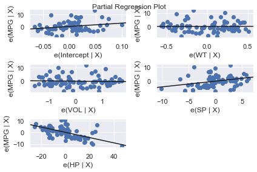

[figure not shown]

```python
sm.graphics.plot_partregress_grid(model2) # model after droppint 76 item from data frame
```

Feature selection model is not present in stats model so we will use sklean model for feature selection here we have to choose manually and take out the variable out here we see weight having more VIF so we removing it 639.533818

```python
# final model
final_ml= smf.ols('MPG~VOL+SP+HP',data =df.drop([df.index[76]])).fit()
final_ml
```

```
<statsmodels.regression.linear_model.RegressionResultsWrapper at 0x1ec8d69ffc8>
```

```python
print(final_ml.summary()) # Rsquared value is 81% its a good model
```

```
                            OLS Regression Results
==============================================================================
Dep. Variable:                    MPG   R-squared:                       0.819
Model:                            OLS   Adj. R-squared:                  0.812
Method:                 Least Squares   F-statistic:                     114.8
Date:                Sun, 19 Jul 2020   Prob (F-statistic):           3.78e-28
Time:                        20:42:54   Log-Likelihood:                -222.00
No. Observations:                  80   AIC:                             452.0
Df Residuals:                      76   BIC:                             461.5
Df Model:                           3
Covariance Type:            nonrobust
==============================================================================
                 coef    std err          t      P>|t|      [0.025      0.975]
------------------------------------------------------------------------------
Intercept     27.7555     12.922      2.148      0.035       2.018      53.493
VOL           -0.1729      0.021     -8.178      0.000      -0.215      -0.131
SP             0.4124      0.139      2.963      0.004       0.135       0.690
HP            -0.2268      0.035     -6.525      0.000      -0.296      -0.158
==============================================================================
Omnibus:                        9.859   Durbin-Watson:                   1.125
Prob(Omnibus):                  0.007   Jarque-Bera (JB):                9.686
Skew:                           0.767   Prob(JB):                      0.00788
Kurtosis:                       3.742   Cond. No.                     5.77e+03
==============================================================================

Warnings:
[1] Standard Errors assume that the covariance matrix of the errors is correctly specified.
[2] The condition number is large, 5.77e+03. This might indicate that there are
strong multicollinearity or other numerical problems.
```

## Lets do it by sklearn Spliting our data training and test

```python
df1 = df.loc[76]
df1 = df.drop([df.index[76]])
df1 # 76 the item is removed
```

|  | HP | MPG | VOL | SP | WT |
| --- | --- | --- | --- | --- | --- |
| 0 | 49 | 53.700681 | 89 | 104.185353 | 28.762059 |
| 1 | 55 | 50.013401 | 92 | 105.461264 | 30.466833 |
| 2 | 55 | 50.013401 | 92 | 105.461264 | 30.193597 |
| 3 | 70 | 45.696322 | 92 | 113.461264 | 30.632114 |
| 4 | 53 | 50.504232 | 92 | 104.461264 | 29.889149 |
| ... | ... | ... | ... | ... | ... |
| 75 | 175 | 18.762837 | 129 | 132.864163 | 42.778219 |
| 77 | 238 | 19.197888 | 115 | 150.576579 | 37.923113 |
| 78 | 263 | 34.000000 | 50 | 151.598513 | 15.769625 |
| 79 | 295 | 19.833733 | 119 | 167.944460 | 39.423099 |
| 80 | 236 | 12.101263 | 107 | 139.840817 | 34.948615 |

80 rows × 5 columns

```python
df1.columns # viewing the columns indicating our data frame
```

```
Index(['HP', 'MPG', 'VOL', 'SP', 'WT'], dtype='object')
```

```python
X = df1[['HP', 'VOL', 'SP', 'WT']] # my feature variable
```

```python
Y = df1[['MPG']] # my target variabe
```

```python
from sklearn.model_selection import train_test_split
```

```python
X_train, X_test, Y_train, Y_test = train_test_split(X,Y,test_size = 0.4,random_state=101)
```

# Creating and training the model

```python
from sklearn.linear_model import LinearRegression
```

```python
lm = LinearRegression()
```

```python
lm.fit(X_train,Y_train)
```

```
LinearRegression(copy_X=True, fit_intercept=True, n_jobs=None, normalize=False)
```

## Model Evaluation again

```python
#print the intercept
print(lm.intercept_)
```

```
[39.40075023]
```

```python
lm.coef_ # cofficient of our model
```

```
array([[-0.19660245,  0.09708058,  0.29981927, -0.87615408]])
```

## Prediction of our model

```python
predictions = lm.predict(X_test)
```

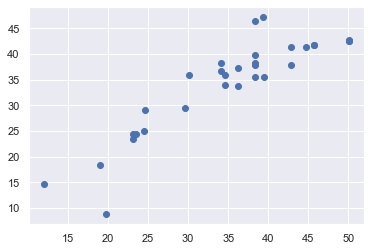

```python
plt.scatter(Y_test,predictions)
```

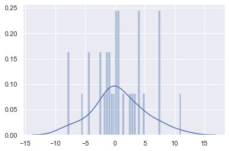

```python
sns.distplot((Y_test-predictions),bins=50)
```

# Feature selection model

```python
from sklearn.feature_selection import RFE
```

```python
lm = LinearRegression()
```

```python
rfe = RFE(lm, 3)
```

```python
rfe = rfe.fit(X_train, y_train)
```

```python
print(rfe.support_)
```

```
[ True  True  True False]
```

```python
print(rfe.ranking_)
```

```
[1 1 1 2]
```

```python
X # From above rfe Ranking we Dropping feature Weight as below it is not required in our model
```

|  | HP | VOL | SP | WT |
| --- | --- | --- | --- | --- |
| 0 | 49 | 89 | 104.185353 | 28.762059 |
| 1 | 55 | 92 | 105.461264 | 30.466833 |
| 2 | 55 | 92 | 105.461264 | 30.193597 |
| 3 | 70 | 92 | 113.461264 | 30.632114 |
| 4 | 53 | 92 | 104.461264 | 29.889149 |
| ... | ... | ... | ... | ... |
| 75 | 175 | 129 | 132.864163 | 42.778219 |
| 77 | 238 | 115 | 150.576579 | 37.923113 |
| 78 | 263 | 50 | 151.598513 | 15.769625 |
| 79 | 295 | 119 | 167.944460 | 39.423099 |
| 80 | 236 | 107 | 139.840817 | 34.948615 |

80 rows × 4 columns

# Again making and evaulating model

```python
x= df1[['HP', 'VOL', 'SP',]]
```

```python
x
```

|  | HP | VOL | SP |
| --- | --- | --- | --- |
| 0 | 49 | 89 | 104.185353 |
| 1 | 55 | 92 | 105.461264 |
| 2 | 55 | 92 | 105.461264 |
| 3 | 70 | 92 | 113.461264 |
| 4 | 53 | 92 | 104.461264 |
| ... | ... | ... | ... |
| 75 | 175 | 129 | 132.864163 |
| 77 | 238 | 115 | 150.576579 |
| 78 | 263 | 50 | 151.598513 |
| 79 | 295 | 119 | 167.944460 |
| 80 | 236 | 107 | 139.840817 |

80 rows × 3 columns

```python
lm1 = LinearRegression()
```

```python
lm1
```

```
LinearRegression(copy_X=True, fit_intercept=True, n_jobs=None, normalize=False)
```

```python
from sklearn.model_selection import train_test_split
```

```python
x_train, x_test, Y_train, Y_test = train_test_split(x,Y,test_size = 0.4,random_state=101)
```

```python
lm1.fit(x_train,Y_train)
```

```
LinearRegression(copy_X=True, fit_intercept=True, n_jobs=None, normalize=False)
```

```python
print(lm1.intercept_)
```

```
[41.11018054]
```

```python
print(lm1.coef_)
```

```
[[-0.19309932 -0.19787556  0.28832068]]
```

# Prediction of our model

```python
pred = lm1.predict(x_test)
```

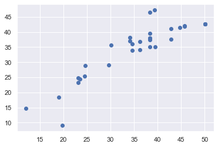

```python
plt.scatter(Y_test,pred)
```

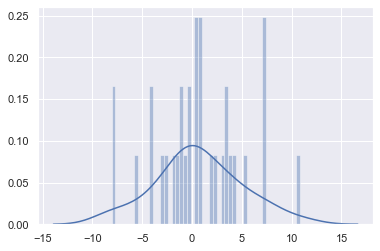

```python
sns.distplot((Y_test-pred),bins=50)
```

```python
final_linear_model = lm1  # our final model evaulated
```

# Lets Evaulates our Regression metrices

We can see our regression model in terms of errors in the model

```python
from sklearn import metrics
```

```python
print('MAE:',metrics.mean_absolute_error(Y_test,pred))
```

```
MAE: 3.321438247174835
```

```python
print('MSE:', metrics.mean_squared_error(Y_test, pred))
```

```
MSE: 18.835182601304567
```

```python
print('RMSE:', np.sqrt(metrics.mean_squared_error(Y_test, pred)))
```

```
RMSE: 4.339951912326284
```

```python
final_linear_model = lm1  # our final model evaulated
```

```python
lm1
```

```
LinearRegression(copy_X=True, fit_intercept=True, n_jobs=None, normalize=False)
```